# ripInverts - paper content

```r
source("../scripts/ripInverts-paper-code_1.R", chdir = T)
```

## 3 Methods

### 3.2 Comparison between pit falling and timed hand searches.

We explored effect of sampling type on the the composition of the communities we recorded. The similarity of the presence/absence data between each two replicates was quantified using the Jaccard index. Permutational Multivariate Analysis of Variance (PERMANOVA) was carried out on the resulting similarity matrix to establish the contribution of event, river and sample type to the variance of similarity. All this was carried out in one step using the R function vegan::adonis2. [citations to be added]

### 3.4. To what extent do sampling events adequately represent the full diversity of riparian beetles present along any given stretch?

We examined the completeness of the riparian beetle inventory by creating species accumulation curves which plot the number of species against sampling effort. In most cases, we used number of replicates as the measure of sampling effort, although we also considered events and event/sample-type. Species accumulation curves were fitted using the R function vegan::specaccum. As the probability of finding a new species with an additional sample approaches zero, species accumulation curves reach an asymptote. We considered it sufficient to judge this by eye using graphs of the relevant curves. [citations to be added]

## 4 Results and Conclusions

### 4.2 Comparison between pit falling and timed hand searches.

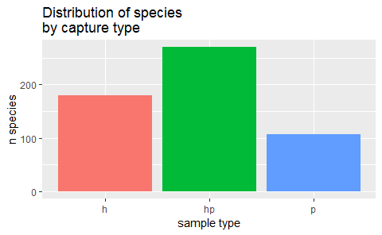

```r
ggplot(obs_all_freq_types, aes(sample_types)) +
  geom_bar(aes(fill = sample_types)) +
  theme(legend.position = "none") +
  labs(title = "Distribution of species \nby capture type",
       x = "sample type", y = "n species")
```

Of these, 300 are wetland species, and 225 are not. Wetland species were caught by pitfall only in significantly lower proportions to non-wetland species, but significantly higher proportion of species was caught by both handfall and pitfall methods (Pearson’s Chi-squared test, X-squared = 39.0950277, df = 2, p = 0)

```
Using alpha for a discrete variable is not advised.Warning messages:
1: Unknown or uninitialised column: 'river'.
2: Unknown or uninitialised column: 'river'.
```

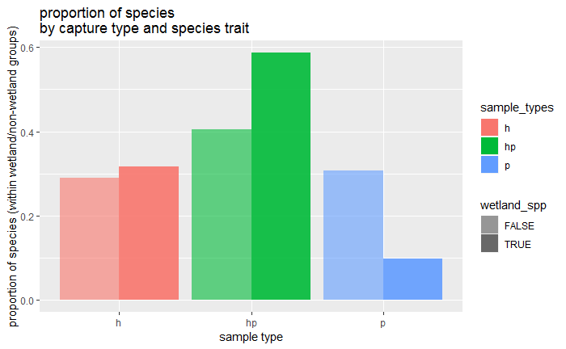

```r
ggplot(graphdata, aes(x = sample_types, y = prop)) +
  geom_bar(aes(fill = sample_types, alpha = wetland_spp), position = position_dodge(), stat = "identity") +
  scale_alpha_discrete(range = c(0.6, 0.9))+
  labs(title = "proportion of species \nby capture type and species trait",
       x = "sample type", y = "proportion of species (within wetland/non-wetland groups)")
```

```
Using alpha for a discrete variable is not advised.
```

[figure not shown]

```r
ggplot(obs_all_freq_types, aes(y = length.min, x = sample_types)) +
  geom_boxplot() +
  scale_alpha_discrete(range = c(0.6, 0.9))+
  labs(title = "Distribution of species \nby capture type and minimum length",
       y = "number of species", x = "minimum length (mm)")
```

[figure not shown]

```r
#create formatted outputs for dissimilarity
adon1_results <- paste0(adon1$Df, " Df, F = ", round(adon1$F, 2), ", p = ", round(adon1$`Pr(>F)`, 4))
names(adon1_results) <- row.names(adon1)
```

After controlling for river and event, sample type makes a significant contribution to the dissimilarity between samples (1 Df, F = 8.11, p = 0.0083)

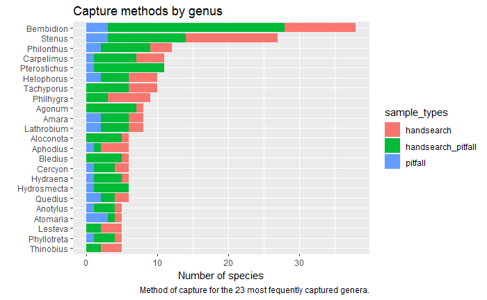

```r
genus_levels <- genus_types$genus[order(-genus_types$n_spp)]
min_n_spp <- 4
graphdata <- genus_types %>%
  ungroup() %>%
  filter(n_spp > min_n_spp) %>%
  arrange(-n_spp) %>%
  mutate(genus = factor(genus, levels = rev(genus))) %>%
  select(-n_spp) %>%
  gather(key = sample_types,
         value = n_spp, handsearch, pitfall, handsearch_pitfall) %>%
  droplevels()
n_genus <- length(unique(graphdata$genus))
ggplot(graphdata, aes(y = n_spp, x = genus, fill = sample_types)) +
  geom_col() +
  coord_flip() +
  labs(title = "Capture methods by genus",
       caption = paste0("Method of capture for the ", n_genus, " most fequently captured genera."),
      y = "Number of species", x = "")
```

```r
# genus_types %>%
#   ungroup() %>%
#   filter(n_spp < min_n_spp) %>%
#   arrange(-n_spp) %>%
#   mutate(genus = factor(genus, levels = rev(genus))) %>%
#   select(-n_spp) %>%
#   gather(key = sample_types,
#          value = n_spp, handsearch, pitfall, handsearch_pitfall) %>%
#   filter(n_spp > 0) %>%
#   count(sample_types)
```

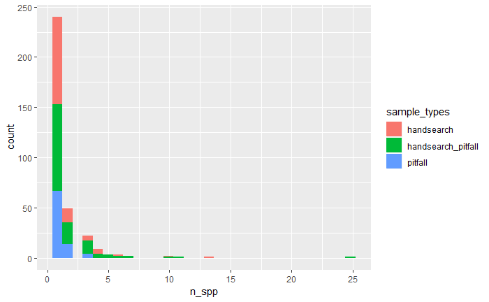

```r
genus_levels <- genus_types$genus[order(-genus_types$n_spp)]
min_n_spp <- 0
graphdata <- genus_types %>%
  ungroup() %>%
  filter(n_spp > min_n_spp) %>%
  arrange(-n_spp) %>%
  mutate(genus = factor(genus, levels = rev(genus))) %>%
  select(-n_spp) %>%
  gather(key = sample_types,
         value = n_spp, handsearch, pitfall, handsearch_pitfall) %>%
  filter(n_spp > 0) %>%
  droplevels()
n_genus <- length(unique(graphdata$genus))
ggplot(graphdata, aes(x = n_spp, fill = sample_types)) +
  geom_histogram()
```

### 4.4 To what extent do sampling events adequately represent the full diversity of riparian beetles present along any given stretch?

```r
plot(spec_accum_selected, ci.type = "polygon", ci.col = "grey", ci.lty = "dotted",
     main = "Species accumulation curve: grand total")
abline(h = max(spec_accum_selected$richness), col = "black")
```

[figure not shown]

```r
abline(h = max(spec_accum_selected$richness)*0.95, col = "red")
abline(h = max(spec_accum_selected$richness)*0.9, col = "red", lty = "dotted")
```

```r
graphdata <- spec_accum_byriver
#colours <- c("hand_search" = "royalblue", "excavation" = "green", "pitfall" = "red")
legenddata <- graphdata %>% group_by(river) %>% summarise(max_sites = max(n_sites))
```

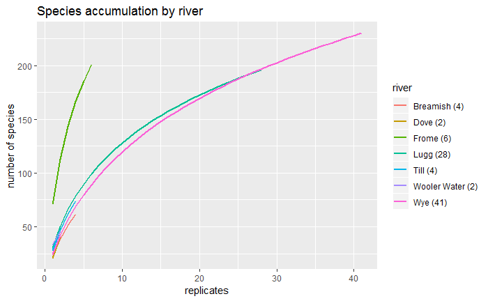

```r
ggplot(graphdata, aes(x = n_sites, y = n_spp, colour = river))+
  geom_line(size = 1) +
  scale_colour_discrete(labels = paste0(legenddata$river, " (", legenddata$max_sites, ")"))+
  labs(title = "Species accumulation by river", x = "replicates", y = "number of species") +
  NULL
```

```r
graphdata <- spec_accum_byevent
legenddata <- graphdata %>% group_by(event_code) %>% summarise(max_sites = max(n_sites))
```

It may be that this is due to the heterogeneity of species compositions along rivers - this should be reduced at the event level. Unfortunately, at the level of events the greatest level of replication is n = 9 samples. It can be seen that this is insufficient replication for the species accumulation curve to reach an asymptote.

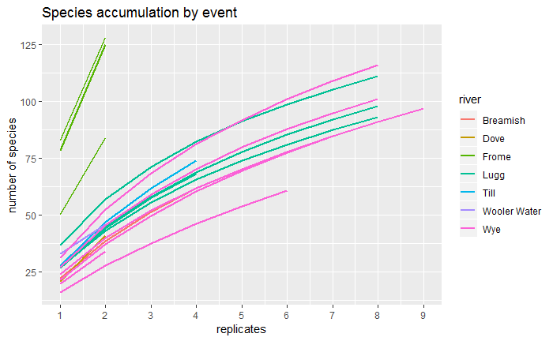

```r
ggplot(graphdata, aes(x = n_sites, y = n_spp, group = event_code, colour = river))+
  geom_line(size = 1) +
   scale_x_continuous(breaks = 1:max(graphdata$n_sites))+
  labs(title = "Species accumulation by event", x = "replicates", y = "number of species") +
  NULL
```

The last remaining source of sampling variability is is the type of sample (hand search or pitfall) and we looked at whether splitting by these results in a sample reaching an asymptote within an event. Here we have even less replication (max is n = 5, the majority are n = 4 or lower) and it is clear that no asymptote is reached.

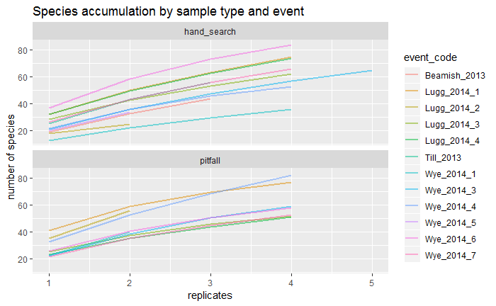

```r
graphdata <- spec_accum_bysampletype
colours <- c("hand_search" = "royalblue", "pitfall" = "red")

ggplot(graphdata, aes(x = n_sites, y = n_spp))+
  geom_line(size = 1, aes(colour = event_code), alpha = 0.5) +
  facet_wrap(~sample_type, ncol = 1)+
  labs(title = "Species accumulation by sample type and event", x = "replicates", y = "number of species") +
  NULL
```

We therefore conclude that the proposed method is not capable of sampling the full abundance of species even at replication of 40 samples for a single river. It is not known what level of replication would be sufficient.